# Python Crash Courses: Intro to Data

- Juputer Notebooks
- Pandas
- Data Visualization
- More Pandas
- Other Packages
- Continued Learning

# Jupyter Notebooks

## Literate Programming

Literate programming combines computer code with natural language to document and explain the code. This idea expands on the way we've used comments and pseudocode to organize and document our code directly in a .py file.

### Use Cases

- **Data Science:** Literate programming allows you to share code with descriptions and context to make interpretation and adaptation easier. Code outputs might include tables, summaries of analyses, and data visualizations.
- **Open / Reproducible / Replicable Science:** Embed code in an article format allows others to examine and re-use specific code for reproduction or replication alongside traditional prose explanation.
- **Education:** This workshop series was created with literate programming via Jupyter Notebooks.
- [**Examples in Jupyter Notebooks**](https://github.com/jupyter/jupyter/wiki/A-gallery-of-interesting-Jupyter-Notebooks)

## Jupyter Notebooks

The documentation for our series of Python workshops are an application of literate programming using a tool called Jupyter Notebooks.

Jupyter Notebooks save as **.ipynb** files (Jupyter Notebooks were previously called IPython Notebooks).

Jupyter Lab provides an interface for Jupyter that will eventually replace the classic Jupyter Notebook interface some of you may have encountered before. You can launch it by opening the Prompt/Terminal:

- (PC) Start Menu > Miniforge3 > Miniforge Prompt
- (Mac) Finder > Applications > Utilities > Terminal

And typing: `jupyter lab`. Note that the older interface is available by typing `jupyter notebook` instead.

Once Jupyter Lab opens in your browser, you can use the Launcher tab or **File Menu>New>Notebook** to create a Jupyter Notebook in a tab.

We'll work with Jupyter Lab for the remainder of the workshop!

## Other Resources:

### [Binder](https://mybinder.org/)

Binder is a free, non-profit, online service that hosts fully functional Jupyter Notebooks. You can view this workbook at: https://mybinder.org/v2/gh/UNC-Libraries-data/Python/main?filepath=Data/Data

In the interface, choose "Jupyter-Notebooks.ipynb" to open this workbook interactively.

### Open OnDemand

Jupyter Lab is also available via [Open OnDemand](https://help.rc.unc.edu/ondemand)

## Cells

Each Jupyter Notebook is made up of individual cells of different types:

- **Markdown** for formatted text
- **Code** for Python

Each type of cell needs to be "Run" to display formatted text or evaluate Python code.

#### Command and Edit Modes

##### Edit Mode

Double click or click and press enter on a cell to enter Edit Mode on a Markdown Cell. Click once for Python cells. This allows you to change the code or markdown within.

##### Command Mode

Click to the left of the cell, or hit Esc in a cell already in Edit mode to enter Command Mode. This allows you to add, copy and paste, or rearrange cells, or change the mode of a cell with keyboard shortcuts.

### Adding and Deleting Cells

Click the + button at the top left to add cells (below) or use these shortcuts to insert cells from **Command Mode**:

- `a` (insert cell above)
- `b` (insert cell below)

Inside each cell, use the dropdown menu on the toolbar to choose between "Markdown" and "Code".

Right click a cell and choose "Delete cell" or press the D key *twice* in Command mode to remove a cell.

### Markdown

Markdown is a convenient shorthand way to write HTML. A full introduction to the syntax is available [here](https://jupyter-notebook.readthedocs.io/en/stable/examples/Notebook/Working%20With%20Markdown%20Cells.html).

A few of the most important pieces of syntax are:

- `# ## ###` ... represent ... level 1, 2, 3 headers respectively
- `*text*` ... displays as ... *text*
- `**text**` ... displays as ... **text**
- `` `text` `` ... displays as ... `text`
- `[UNC home](http://unc.edu)` ... displays as ... [UNC home](http://unc.edu)
- `![Star Blur Photo](https://picsum.photos/id/1042/300/200)` ... displays as ...
  - Image from [Unsplash.com](https://unsplash.com/) via [Lorem Picsum](https://picsum.photos/)

[figure not shown]

If necessary, you can also use html directly in your Markdown cells.

#### Bullets and Lists

**Note:** Be careful to include the space after each asterisk and indentation before subpoints.

Markdown

Displays As

```
* Bullet 1
    * Sub 1
* Bullet 2
    + Sub 1
```

- Bullet 1
  - Sub 1
- Bullet 2
  - Sub 1

```
1. Item 1
2. Item 2
```

1. Item 1
2. Item 2

#### Exercise

1. Create a markdown cell with a header, some plain text with at least one bold or italicized word, and a list (bulleted or numbered). If you're working in this document, you can use the cell below.

**Exercise Cell**

### Code

Code cells follow normal Python Syntax, and when run produce outputs:

```python
72*3
```

```
216
```

#### Exercise

1. Create a code cell, or use the cell below to call the `print` function on a string of your choice. Then run your code to produce an output.

```python
#Excerise Cell
```

As usual, you'll want your notebook to contain all of the necessary statements importing packages and defining all variables used. Cells need to be run in order! Once run, each Python cell will be labeled like `In [<number>]` and each output will be labeled `Out [<number>]`. This helps you keep track of the order cells have been run in.

You can run cells individually as you develop a notebook, but once you're done it's good practice to use Kernel > Restart & Run All to reset your Python instance and make sure your code is actually self-contained.

#### Paths

Jupyter Notebooks automatically set your working directory to the folder where the .ipynb is saved. You'll have to save the document at least once to set your directory.

For example, the csv (comma separated values) file "library_data.csv" is stored in the same folder as this notebook, and it appears in `oslistdir(".")` without setting any working directory first.

```python
import os
os.listdir(".")
```

```
['.Rhistory',
 'PandasSolutions.ipynb',
 'Setup.md',
 'images',
 'PandasSolutions.html',
 'Data.html',
 'Merging_Concatenating_Alternative.ipynb',
 'PandasExercises.ipynb',
 'index.md',
 'UNC_logo.png',
 'PandasExercises.html',
 'CountyHealthData_2014-2015.csv',
 'library_data.csv',
 'Data.ipynb']
```

## Resources

Read more in the Official Docmentation:

- [Jupyter Notebooks](https://jupyter-notebook.readthedocs.io/en/stable/index.html)
- [Jupyter Lab](https://jupyterlab.readthedocs.io/en/stable/index.html)

# Pandas

Like spreadsheets in Microsoft Excel or dataframes in R, Pandas allows us to store our data in tabular, multi-dimensional objects (dataframes) with familiar features like rows, columns, and headers. This is useful because it makes management, manipulation, and cleaning of large datasets much easier than would be the case using Python's built-in data structures such as lists and dictionaries. Pandas also provides a wide range of useful tools for working with data once it has been stored and structured.

We will be working with a synthetic dataset that has been created to for practicing in Python. It doesn't include any real information, but is instead made up of fake circulation data about imaginary books, libraries and towns.

Download the csv file library_data.csv. I've stored my copy in the same folder as this Jupyter Notebook. Remember that Jupyter Notebooks automatically set your working directory to the folder where the .ipynb is saved. You'll have to save the document at least once to set your directory, but once there you can use relative paths.

`pd.read_csv` reads the tabular data from a Comma Separated Values (csv) file into a `DataFrame` object.

```python
import pandas as pd

df = pd.read_csv("library_data.csv")

# Having trouble saving your file to the right location? Try uncommenting and running the line of code below.
#df = pd.read_csv("https://github.com/UNC-Libraries-data/Python/raw/main/Session2/library_data.csv")
```

## Exploring a Data Frame

### Attributes

A good first step in understanding our DataFrame is to examine some of its basic attributes. Attributes contain **values** that help us understand and use the dataframe.

Here we use the `.shape` attribute to determine how many rows and columns (in that order) are available. `.columns` provides the column names for the DataFrame.

```python
df.shape
```

```
(5914, 7)
```

```python
df.columns
```

```
Index(['id', 'library', 'town', 'town pop', 'title', 'genre', 'borrow_date'], dtype='object')
```

### Methods

Much of the functionality for working with dataframes comes in the form of methods. Methods are specialized **functions** that only work for a certain type of object - in this case, dataframes.

We can look at the first 5 rows in the dataset directly with the `.head()` method. Alternatively, we can get a random sample of rows using `sample()`. Note that we supply the parameter n to specify how many rows we want to sample.

```python
df.head()
```

|  | id | library | town | town pop | title | genre | borrow_date |
| --- | --- | --- | --- | --- | --- | --- | --- |
| 0 | 491 | Heritage Heights Library | Hilltop Springs | 75000 | Secrets of the Old Manor | Mystery | 1/1/2020 |
| 1 | 3553 | Meadowbrook Commons Library | Meadowbrook | 45000 | The Enchanted Forest | Fantasy | 1/1/2020 |
| 2 | 3384 | Riverside Reading Room | Riverdale | 150000 | The Dragon's Crown | Fantasy | 1/2/2020 |
| 3 | 2267 | Heritage Heights Library | Hilltop Springs | 75000 | Letters to Forever | Romance | 1/2/2020 |
| 4 | 4298 | Lakeside Reading Center | Lake Haven | 15000 | Mathematics Made Simple | Non-Fiction | 1/2/2020 |

```python
df.sample(n=5)
```

|  | id | library | town | town pop | title | genre | borrow_date |
| --- | --- | --- | --- | --- | --- | --- | --- |
| 5261 | 4772 | Pine Valley Library | Pine Valley | 25000 | Pioneer's Tale | Biography | 6/17/2024 |
| 3651 | 216 | Meadowbrook Commons Library | Meadowbrook | 45000 | Secrets of the Old Manor | Mystery | 3/8/2023 |
| 5805 | 3699 | Riverside Reading Room | Riverdale | 150000 | The Last Spell | Fantasy | 12/3/2024 |
| 2445 | 4974 | Heritage Heights Library | Hilltop Springs | 75000 | Nature's Poetry | Poetry | 2/15/2022 |
| 4908 | 925 | Riverside Reading Room | Riverdale | 150000 | Murder on Pine Street | Mystery | 3/5/2024 |

A full list of attributes and methods for DataFrames is available in the [documentation](https://pandas.pydata.org/docs/reference/api/pandas.DataFrame.html).

## Indexing

We'll often want to select certain rows or columns from a large dataframe. As with elements in a list, this can be accomplished using indexing. There are some limitations, however. For example, we can use numbers in square brackets to select certain rows, but doing so always returns all the columns in our dataset:

```python
df[0:3]
```

|  | id | library | town | town pop | title | genre | borrow_date |
| --- | --- | --- | --- | --- | --- | --- | --- |
| 0 | 491 | Heritage Heights Library | Hilltop Springs | 75000 | Secrets of the Old Manor | Mystery | 1/1/2020 |
| 1 | 3553 | Meadowbrook Commons Library | Meadowbrook | 45000 | The Enchanted Forest | Fantasy | 1/1/2020 |
| 2 | 3384 | Riverside Reading Room | Riverdale | 150000 | The Dragon's Crown | Fantasy | 1/2/2020 |

We can select rows for specific columns using the column names. If we want to select multiple columns, we must list them in their own nested set of square brackets.

```python
df["title"][5:10]
```

```
5    Secrets of the Old Manor
6          The Dragon's Crown
7                Time Paradox
8       Murder on Pine Street
9           The Perfect Crime
Name: title, dtype: object
```

```python
df[["title", "genre", "borrow_date"]][20:24]
```

|  | title | genre | borrow_date |
| --- | --- | --- | --- |
| 20 | The Perfect Crime | Thriller | 1/6/2020 |
| 21 | Secrets of the Old Manor | Mystery | 1/6/2020 |
| 22 | The Silent Witness | Thriller | 1/7/2020 |
| 23 | Wizard's First Rule | Fantasy | 1/7/2020 |

#### `.iloc`

If we use the .iloc attribute before our brackets, pandas accepts two numbers separated by a comma. The first number is for rows and the second for columns. Below, we select the second row and sixth column.

```python
df.iloc[2,6]
```

```
'1/2/2020'
```

We can also use a colon to select multiple rows or columns at once. Note the examples below.

```python
df.iloc[:,1] # All rows of column 1
```

```
0          Heritage Heights Library
1       Meadowbrook Commons Library
2            Riverside Reading Room
3          Heritage Heights Library
4           Lakeside Reading Center
                   ...
5909         Riverside Reading Room
5910       Heritage Heights Library
5911       Heritage Heights Library
5912    Meadowbrook Commons Library
5913       Heritage Heights Library
Name: library, Length: 5914, dtype: object
```

```python
df.iloc[0:3,:] # Rows 0-2 of all columns
```

|  | id | library | town | town pop | title | genre | borrow_date |
| --- | --- | --- | --- | --- | --- | --- | --- |
| 0 | 491 | Heritage Heights Library | Hilltop Springs | 75000 | Secrets of the Old Manor | Mystery | 1/1/2020 |
| 1 | 3553 | Meadowbrook Commons Library | Meadowbrook | 45000 | The Enchanted Forest | Fantasy | 1/1/2020 |
| 2 | 3384 | Riverside Reading Room | Riverdale | 150000 | The Dragon's Crown | Fantasy | 1/2/2020 |

```python
df.iloc[120:126,1:4] # Rows 120-125 of columns 1-3
```

|  | library | town | town pop |
| --- | --- | --- | --- |
| 120 | Riverside Reading Room | Riverdale | 150000 |
| 121 | Riverside Reading Room | Riverdale | 150000 |
| 122 | Riverside Reading Room | Riverdale | 150000 |
| 123 | Meadowbrook Commons Library | Meadowbrook | 45000 |
| 124 | Riverside Reading Room | Riverdale | 150000 |
| 125 | Heritage Heights Library | Hilltop Springs | 75000 |

### `.loc`

The **i** in `iloc` stands for **integer**. If we still want to use the column names, we can use the `.loc` attribute instead.

```python
df.loc[0:3,"title"]
```

```
0    Secrets of the Old Manor
1        The Enchanted Forest
2          The Dragon's Crown
3          Letters to Forever
Name: title, dtype: object
```

```python
df.loc[0:3,["title","genre"]]
```

|  | title | genre |
| --- | --- | --- |
| 0 | Secrets of the Old Manor | Mystery |
| 1 | The Enchanted Forest | Fantasy |
| 2 | The Dragon's Crown | Fantasy |
| 3 | Letters to Forever | Romance |

Indexing in pandas can also be combined with methods. Here, we'll use the `head()` method while indexing with .loc.

```python
df.loc[:,["title","genre"]] .head()
```

|  | title | genre |
| --- | --- | --- |
| 0 | Secrets of the Old Manor | Mystery |
| 1 | The Enchanted Forest | Fantasy |
| 2 | The Dragon's Crown | Fantasy |
| 3 | Letters to Forever | Romance |
| 4 | Mathematics Made Simple | Non-Fiction |

### Indexing and Assignment

When we want to assign a value into a cell or region of our DataFrame, it's best practice to use the `.loc` or `.iloc` attributes to select a region of our dataset. This ensures that when changes are made, they will flow back into the original DataFrame and not into a copy. This is a particularly common problem when using multiple indices stacked on top of each other. Unfortunately this problem is inherently unpredictable in Pandas, and can best be avoided by using the `.loc` and `.iloc` attributes.

Read more [here](https://pandas.pydata.org/pandas-docs/stable/user_guide/indexing.html#why-does-assignment-fail-when-using-chained-indexing).

Try running the commented out code `ex["County"][0] = "New County"` below, after creating `ex`. Both may work, but the commented version will throw a `SettingwithCopyWarning` warning and may sometimes fail.

```python
ex = df.copy()

#Do this:
ex.loc[0,"library"] = "New Library"

#NOT this:
#ex["County"][0] = "New County"

print(ex.loc[0,"library"])
```

```
New Library
```

## Series

We can think of a DataFrame as a collection rows and columns where each row represents an "observation" and each column contains a specific type of information collected about each observation. In Pandas, our columns are stored as Series objects. A DataFrame, like a dictionary, can be thought of as a named collection of objects, but in this case, the objects are Series.

Series have their own set of attributes and methods just like DataFrames. One of the most useful methods for categorical variables is .value_counts() which provides a frequency table.

We can extract a single column in a couple of ways:

- bracket notation: `df["library"]` - this is the most robust way to refer to Series
- dot notation: `df.library` - simpler and easier to read but not always available

```python
all(df.library==df["library"]) #check if all entries of the two Series are the same.
```

```
True
```

In some cases, dot notation does not work! The most common situations are:

- The column name has a space, or other irregularities
- The column name is the same as an existing attribute or method

For example, in our DataFrame, `df.ton pop` doesn't understand that "town pop" is a single value, so instead we'd use `df["town pop"]`

Series have their own set of attributes and methods just like DataFrames. Some attributes like `.dtypes` and `.shape` are available for both.

One of the most useful methods for categorical variables is `.value_counts()` which provides a frequency table.

```python
# How many books have been borrowed at each library?
df.library.value_counts()
```

```
library
Heritage Heights Library       1864
Riverside Reading Room         1853
Meadowbrook Commons Library    1239
Pine Valley Library             649
Lakeside Reading Center         309
Name: count, dtype: int64
```

This can also be used on top of other attributes or methods that return series. For example, the code below shows how frequently each data type appears in our DataFrame.

```python
df.dtypes.value_counts()
```

```
object    5
int64     2
Name: count, dtype: int64
```

### Filtering

To filter our dataset based on a logical condition (true or false), we will use nested square brackets. Note the example below.

- The inner statement, `df["borrow_date"]=="6/23/2024"` looks for a **column** name and checks if it equals "6/23/2024"
- The outer statement `df[ ... ]` uses the resulting column of True/Falue values to select **rows**
- When combined, these two commands call all of the data contained in rows where the value of the borrow_date field is equal to "6/23/2024"

```python
# What books were borrowed on 6/23/2024?
df[df["borrow_date"] == "6/23/2024"]
```

|  | id | library | town | town pop | title | genre | borrow_date |
| --- | --- | --- | --- | --- | --- | --- | --- |
| 5283 | 1271 | Riverside Reading Room | Riverdale | 150000 | The Last Space Colony | Science Fiction | 6/23/2024 |
| 5284 | 2906 | Heritage Heights Library | Hilltop Springs | 75000 | The Victorian Secret | Historical Fiction | 6/23/2024 |
| 5285 | 4864 | Heritage Heights Library | Hilltop Springs | 75000 | The Inventor's Life | Biography | 6/23/2024 |
| 5286 | 4551 | Heritage Heights Library | Hilltop Springs | 75000 | Life of Einstein | Biography | 6/23/2024 |
| 5287 | 3051 | Meadowbrook Commons Library | Meadowbrook | 45000 | Ancient Promises | Historical Fiction | 6/23/2024 |

#### `SettingwithCopyWarning` and filtered data

When we use the notation above to filter a DataFrame we may run into a `SettingwithCopyWarning` warning later on in our code if we save this object and then modify it later on. That's because this notation creates a reference back to the original dataframe, **not** a copy of the original dataframe, unless we explicitly use the **`.copy()`** method. If you want to use subset later on, you should create it as follows:

```python
june23_df = df[df["borrow_date"] == "6/23/2024"].copy()
```

## Pandas Training on LinkedIn Learning

- Get free access to [LinkedIn Learning](https://software.sites.unc.edu/linkedin/) through UNC
- Data Analysis with Python and Pandas
- [Getting Started with Pandas and Advanced Pandas](https://www.linkedin.com/learning/advanced-pandas-29724107/getting-started-with-pandas)

# Answering Research Questions With Data Visualization

### Setup

```python
import pandas as pd

df = pd.read_csv("library_data.csv")
```

```python
df.dtypes
```

```
id              int64
library        object
town           object
town pop        int64
title          object
genre          object
borrow_date    object
dtype: object
```

### Research Questions

Without any preparation or planning, trying to explore a dataset can be overwhelming, and you may find yourself unsure of where to begin. The first step to successful Exploratory Data Analysis (EDA) is developing a set of research questions. We will use the questions below to guide our research and create visualizations to answer the questions.

1. What are the top 5 most borrowed books overall and in each library?
2. How does the population of a town relate to borrowing activity?
3. What percent of library transactions are for fiction or nonfiction books?
4. What are the borrowing trends for Secrets of the Old Manor over time?

## What are the top 5 most borrowed books overall?

```python
# Count how often each book has been borrowed
top5 = df.title.value_counts()

# Get only the top 5
top5 = top5.head()

top5
```

```
title
Secrets of the Old Manor     392
The Bookshop Romance         305
Summer Hearts                283
The Detective's Last Case    252
Mathematics Made Simple      231
Name: count, dtype: int64
```

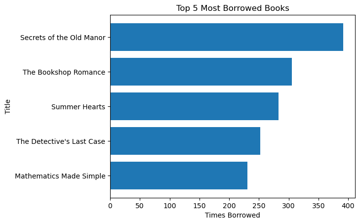

```python
# load matplotlib
import matplotlib.pyplot as plt

# Create horizontal bar chart
plt.barh(y = top5.index, width = top5.values) # set the x and y axis
plt.gca().invert_yaxis() # display bars in descending order
plt.xlabel("Times Borrowed") # label the x axis
plt.ylabel("Title") # label the y axis
plt.title("Top 5 Most Borrowed Books") # create a chart title
```

```python
# Group the df by library
top5bylib = df.groupby("library")

# Count the number of times each book is borrowed in each library. This gives us a series.
top5bylib = top5bylib.title.value_counts()

# Now that we have a series, we need to group it by library again and get the top 5 in each group
top5bylib = top5bylib.groupby("library").nlargest(5)

# Turn the series into a dataframe to make it easier to work with in Seaborn
top5bylib = top5bylib.reset_index(level=0, drop=True).to_frame().reset_index()

top5bylib.head(15)
```

|  | library | title | count |
| --- | --- | --- | --- |
| 0 | Heritage Heights Library | The Detective's Last Case | 102 |
| 1 | Heritage Heights Library | The Silent Witness | 80 |
| 2 | Heritage Heights Library | Secrets of the Old Manor | 79 |
| 3 | Heritage Heights Library | Murder on Pine Street | 76 |
| 4 | Heritage Heights Library | The Missing Manuscript | 76 |
| 5 | Lakeside Reading Center | Secrets of the Old Manor | 68 |
| 6 | Lakeside Reading Center | The Bookshop Romance | 55 |
| 7 | Lakeside Reading Center | Philosophy Today | 42 |
| 8 | Lakeside Reading Center | The Last Space Colony | 40 |
| 9 | Lakeside Reading Center | Life of Einstein | 39 |
| 10 | Meadowbrook Commons Library | The Vanishing at Midnight | 82 |
| 11 | Meadowbrook Commons Library | Deadly Deadline | 80 |
| 12 | Meadowbrook Commons Library | Secrets of the Old Manor | 74 |
| 13 | Meadowbrook Commons Library | The Victorian Secret | 73 |
| 14 | Meadowbrook Commons Library | The Silent Witness | 69 |

## What are the top 5 most borrowed books in each library?

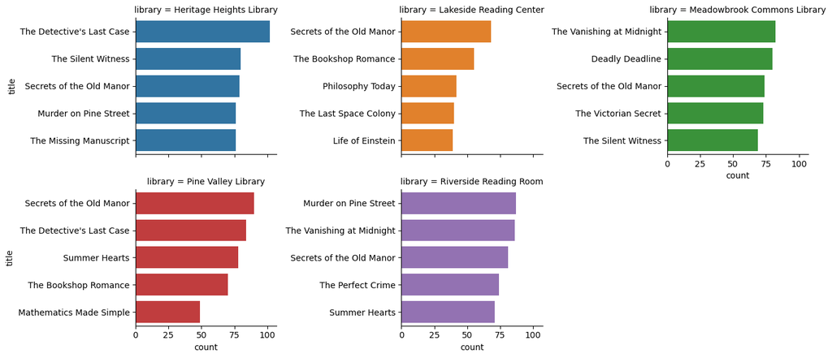

```python
# load seaborn
import seaborn as sns

# create a "grid" object using the FacetGrid function.
grid = sns.FacetGrid(data = top5bylib, col = "library", col_wrap = 3, hue = "library", sharey = False, aspect = 1.5)

# specify which chart we want to use on the grid and supply the variables for the x and y axis.
fig = grid.map_dataframe(sns.barplot, y = "title", x = "count")
```

```python
df.head()
```

|  | id | library | town | town pop | title | genre | borrow_date |
| --- | --- | --- | --- | --- | --- | --- | --- |
| 0 | 491 | Heritage Heights Library | Hilltop Springs | 75000 | Secrets of the Old Manor | Mystery | 1/1/2020 |
| 1 | 3553 | Meadowbrook Commons Library | Meadowbrook | 45000 | The Enchanted Forest | Fantasy | 1/1/2020 |
| 2 | 3384 | Riverside Reading Room | Riverdale | 150000 | The Dragon's Crown | Fantasy | 1/2/2020 |
| 3 | 2267 | Heritage Heights Library | Hilltop Springs | 75000 | Letters to Forever | Romance | 1/2/2020 |
| 4 | 4298 | Lakeside Reading Center | Lake Haven | 15000 | Mathematics Made Simple | Non-Fiction | 1/2/2020 |

## How does the population of a town relate to borrowing activity?

```python
# Get the population and number of library transactions for each town
popactivity = df.groupby("town").agg(townpop = ("town pop", "first"), transactions = ("id", "count"))

popactivity.head()
```

| town | townpop | transactions |
| --- | --- | --- |
| Hilltop Springs | 75000 | 1864 |
| Lake Haven | 15000 | 309 |
| Meadowbrook | 45000 | 1239 |
| Pine Valley | 25000 | 649 |
| Riverdale | 150000 | 1853 |

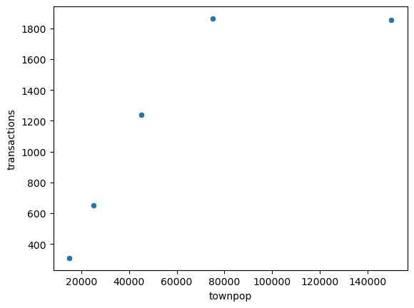

```python
# Create a scatterplot
sns.scatterplot(data = popactivity, x = "townpop", y = "transactions")
plt.show()
```

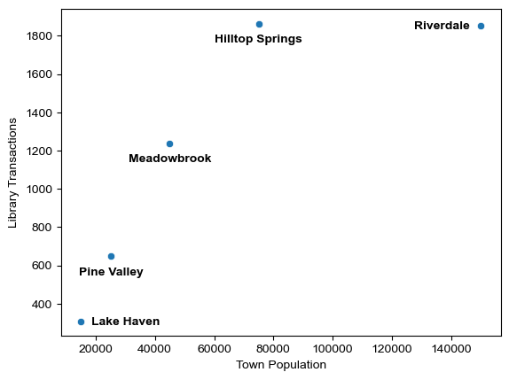

```python
# Create lists of labels and their coordinates
x = popactivity.townpop.values
y = popactivity.transactions.values
xoffset = [0, 15000, 100, 100, -13000]
yoffset = [-100, -20, -100, -100, -20]
labels = popactivity.index

# Assign labels to their coordinates and style them
for i in range(len(popactivity)):
    plt.text(x = x[i] + xoffset[i],
             y = y[i] + yoffset[i],
             s = labels[i],
             ha = "center",
             weight = "bold")

sns.set_style("whitegrid") # Show a grid
plt.xlabel("Town Population") # label the x axis
plt.ylabel("Library Transactions") # label the y axis

sns.scatterplot(data = popactivity, x = "townpop", y = "transactions")
```

## What percent of library transactions are for fiction or nonfiction books?

```python
df.head()
```

|  | id | library | town | town pop | title | genre | borrow_date |
| --- | --- | --- | --- | --- | --- | --- | --- |
| 0 | 491 | Heritage Heights Library | Hilltop Springs | 75000 | Secrets of the Old Manor | Mystery | 1/1/2020 |
| 1 | 3553 | Meadowbrook Commons Library | Meadowbrook | 45000 | The Enchanted Forest | Fantasy | 1/1/2020 |
| 2 | 3384 | Riverside Reading Room | Riverdale | 150000 | The Dragon's Crown | Fantasy | 1/2/2020 |
| 3 | 2267 | Heritage Heights Library | Hilltop Springs | 75000 | Letters to Forever | Romance | 1/2/2020 |
| 4 | 4298 | Lakeside Reading Center | Lake Haven | 15000 | Mathematics Made Simple | Non-Fiction | 1/2/2020 |

```python
import numpy as np

# Assign the "Fiction" genre type to any book that isn't Non-Fiction
df["genre_type"] = np.where(df["genre"] == "Non-Fiction", "Non-Fiction", "Fiction")

df[["id", "genre", "genre_type"]].head()
```

|  | id | genre | genre_type |
| --- | --- | --- | --- |
| 0 | 491 | Mystery | Fiction |
| 1 | 3553 | Fantasy | Fiction |
| 2 | 3384 | Fantasy | Fiction |
| 3 | 2267 | Romance | Fiction |
| 4 | 4298 | Non-Fiction | Non-Fiction |

```python
# Group the df by genre
fvnf = df.groupby("genre_type")

# Count the number of times each book is borrowed in each genre type.
fvnf = fvnf.genre_type.value_counts()

fvnf
```

```
genre_type
Fiction        5208
Non-Fiction     706
Name: count, dtype: int64
```

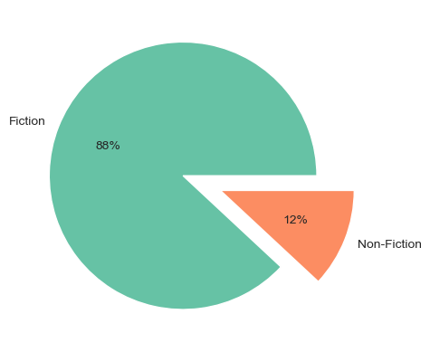

```python
# Use an alternative color palette
colors = sns.color_palette("Set2")

# Create the pie chart
plt.pie(fvnf.values, labels = fvnf.index, colors = colors, autopct='%.0f%%', explode = [0,.3])
plt.show()
```

## What are the borrowing trends for *Secrets of the Old Manor* over time?

```python
# Use a filter to select the title we want to focus on
somtrend = df[df["title"] == "Secrets of the Old Manor"]

# Count the number of times the book is borrowed on each date. This gives us a series.
somtrend = somtrend.borrow_date.value_counts()

# Turn the series into a dataframe
somtrend = somtrend.to_frame().reset_index()

# Give borrow_date a datetime format
somtrend["borrow_date"] = pd.to_datetime(somtrend["borrow_date"])

# Group and sum by month for a smoother line. This gives us a series again.
somtrend = somtrend.groupby(somtrend["borrow_date"].dt.to_period("M"))["count"].sum()

# Turn the series into a dataframe again
somtrend = somtrend.to_frame().reset_index()

# Sort dataframe in chronological order for Bokeh to display it correctly
somtrend = somtrend.sort_values(by="borrow_date")

somtrend.head()
```

|  | borrow_date | count |
| --- | --- | --- |
| 0 | 2020-01 | 10 |
| 1 | 2020-02 | 9 |
| 2 | 2020-03 | 8 |
| 3 | 2020-04 | 6 |
| 4 | 2020-05 | 10 |

```python
# load bokeh modules
from bokeh.plotting import figure, show, output_notebook

# set up bokeh for working in jupyter notebooks
output_notebook()

# set up the size of our plot and format the x axis for dates
p = figure(height = 300, width = 600, x_axis_type = "datetime")

# add a line to our plot
p.line(source = somtrend, x = "borrow_date", y = "count", width = 2)

# show the plot
show(p)
```

Loading BokehJS ...

## Back to Pandas

### Combinging Datasets

We're going back to Pandas o explore we can combine datasets using some built-in Pandas methods.

```python
import pandas as pd
import numpy as np

library_df = pd.read_csv("library_data.csv", encoding='utf-8')
library_df.head()
```

|  | id | library | town | town pop | title | genre | borrow_date |
| --- | --- | --- | --- | --- | --- | --- | --- |
| 0 | 491 | Heritage Heights Library | Hilltop Springs | 75000 | Secrets of the Old Manor | Mystery | 1/1/2020 |
| 1 | 3553 | Meadowbrook Commons Library | Meadowbrook | 45000 | The Enchanted Forest | Fantasy | 1/1/2020 |
| 2 | 3384 | Riverside Reading Room | Riverdale | 150000 | The Dragon's Crown | Fantasy | 1/2/2020 |
| 3 | 2267 | Heritage Heights Library | Hilltop Springs | 75000 | Letters to Forever | Romance | 1/2/2020 |
| 4 | 4298 | Lakeside Reading Center | Lake Haven | 15000 | Mathematics Made Simple | Non-Fiction | 1/2/2020 |

### Concatenating Datasets

##### When to use concatenation?

Use `pd.concat()` when you have datasets with **the same structure** that you want to stack together, such as combining data from different time periods or different sources.

##### Example: Combining Monthly Borrowing Data

The library system collects borrowing data monthly. Let's combine January and February data:

```python
jan_borrows = library_df[library_df["borrow_date"].str.startswith("1/")][:5]
jan_borrows
```

|  | id | library | town | town pop | title | genre | borrow_date |
| --- | --- | --- | --- | --- | --- | --- | --- |
| 0 | 491 | Heritage Heights Library | Hilltop Springs | 75000 | Secrets of the Old Manor | Mystery | 1/1/2020 |
| 1 | 3553 | Meadowbrook Commons Library | Meadowbrook | 45000 | The Enchanted Forest | Fantasy | 1/1/2020 |
| 2 | 3384 | Riverside Reading Room | Riverdale | 150000 | The Dragon's Crown | Fantasy | 1/2/2020 |
| 3 | 2267 | Heritage Heights Library | Hilltop Springs | 75000 | Letters to Forever | Romance | 1/2/2020 |
| 4 | 4298 | Lakeside Reading Center | Lake Haven | 15000 | Mathematics Made Simple | Non-Fiction | 1/2/2020 |

```python
feb_borrows = library_df[library_df["borrow_date"].str.startswith("2/")][:5]
feb_borrows
```

|  | id | library | town | town pop | title | genre | borrow_date |
| --- | --- | --- | --- | --- | --- | --- | --- |
| 110 | 620 | Riverside Reading Room | Riverdale | 150000 | The Detective's Last Case | Mystery | 2/1/2020 |
| 111 | 573 | Pine Valley Library | Pine Valley | 25000 | The Detective's Last Case | Mystery | 2/1/2020 |
| 112 | 3642 | Meadowbrook Commons Library | Meadowbrook | 45000 | Kingdom of Magic | Fantasy | 2/1/2020 |
| 113 | 2603 | Meadowbrook Commons Library | Meadowbrook | 45000 | The Writer's Journey | Literary Fiction | 2/2/2020 |
| 114 | 4049 | Lakeside Reading Center | Lake Haven | 15000 | Philosophy Today | Non-Fiction | 2/2/2020 |

```python
all_borrows = pd.concat([jan_borrows, feb_borrows], axis=0, ignore_index=True)
all_borrows
```

|  | id | library | town | town pop | title | genre | borrow_date |
| --- | --- | --- | --- | --- | --- | --- | --- |
| 0 | 491 | Heritage Heights Library | Hilltop Springs | 75000 | Secrets of the Old Manor | Mystery | 1/1/2020 |
| 1 | 3553 | Meadowbrook Commons Library | Meadowbrook | 45000 | The Enchanted Forest | Fantasy | 1/1/2020 |
| 2 | 3384 | Riverside Reading Room | Riverdale | 150000 | The Dragon's Crown | Fantasy | 1/2/2020 |
| 3 | 2267 | Heritage Heights Library | Hilltop Springs | 75000 | Letters to Forever | Romance | 1/2/2020 |
| 4 | 4298 | Lakeside Reading Center | Lake Haven | 15000 | Mathematics Made Simple | Non-Fiction | 1/2/2020 |
| 5 | 620 | Riverside Reading Room | Riverdale | 150000 | The Detective's Last Case | Mystery | 2/1/2020 |
| 6 | 573 | Pine Valley Library | Pine Valley | 25000 | The Detective's Last Case | Mystery | 2/1/2020 |
| 7 | 3642 | Meadowbrook Commons Library | Meadowbrook | 45000 | Kingdom of Magic | Fantasy | 2/1/2020 |
| 8 | 2603 | Meadowbrook Commons Library | Meadowbrook | 45000 | The Writer's Journey | Literary Fiction | 2/2/2020 |
| 9 | 4049 | Lakeside Reading Center | Lake Haven | 15000 | Philosophy Today | Non-Fiction | 2/2/2020 |

**Common Issue:** What happens when the datasets don't have the same columns?

```python
# March data with an extra column: patron rating
march_borrows = pd.DataFrame({
    "id": [1001, 1007],
    "title": ["Philosophy Today", "Mathematics Made Simple"],
    "library": ["Riverside Reading Room", "Lakeside Reading Center"],
    "town": ["Riverdale", "Lake Haven"],
    "town pop": [150000	, 15000],
    "borrow_date": ["3/5/2024", "3/6/2024"],
    "patron_rating": [5, 4], # new column
    # missing genre column
})
march_borrows
```

|  | id | title | library | town | town pop | borrow_date | patron_rating |
| --- | --- | --- | --- | --- | --- | --- | --- |
| 0 | 1001 | Philosophy Today | Riverside Reading Room | Riverdale | 150000 | 3/5/2024 | 5 |
| 1 | 1007 | Mathematics Made Simple | Lakeside Reading Center | Lake Haven | 15000 | 3/6/2024 | 4 |

```python
mixed_concat = pd.concat([jan_borrows,march_borrows], axis=0, ignore_index=True)
mixed_concat
```

|  | id | library | town | town pop | title | genre | borrow_date | patron_rating |
| --- | --- | --- | --- | --- | --- | --- | --- | --- |
| 0 | 491 | Heritage Heights Library | Hilltop Springs | 75000 | Secrets of the Old Manor | Mystery | 1/1/2020 | NaN |
| 1 | 3553 | Meadowbrook Commons Library | Meadowbrook | 45000 | The Enchanted Forest | Fantasy | 1/1/2020 | NaN |
| 2 | 3384 | Riverside Reading Room | Riverdale | 150000 | The Dragon's Crown | Fantasy | 1/2/2020 | NaN |
| 3 | 2267 | Heritage Heights Library | Hilltop Springs | 75000 | Letters to Forever | Romance | 1/2/2020 | NaN |
| 4 | 4298 | Lakeside Reading Center | Lake Haven | 15000 | Mathematics Made Simple | Non-Fiction | 1/2/2020 | NaN |
| 5 | 1001 | Riverside Reading Room | Riverdale | 150000 | Philosophy Today | NaN | 3/5/2024 | 5.0 |
| 6 | 1007 | Lakeside Reading Center | Lake Haven | 15000 | Mathematics Made Simple | NaN | 3/6/2024 | 4.0 |

#### Merging Datasets

##### When to merge?

Use `pd.merge()` when you have datasets with **different information** about the same entities that you want to join side-by-side using a common key.

##### Example: Adding Book Details to Borrowing Data

We have book metadata in a separate table. Let's join it with our borrowing data:

```python
book_catalog = pd.DataFrame({
    "title": ["Secrets of the Old Manor", "The Enchanted Forest", "The Dragon's Crown", "Letters to Forever", "Mathematics Made Simple"],
    "author": ["Jane Doe", "John Smith", "Emily Johnson", "Michael Brown", "Sarah Davis"],
    "genre": ["Fiction", "Fantasy", "Adventure", "Romance", "Textbook"],
    "year_published": [2010, 2015, 2020, 2022, 2018]
})
book_catalog
```

|  | title | author | genre | year_published |
| --- | --- | --- | --- | --- |
| 0 | Secrets of the Old Manor | Jane Doe | Fiction | 2010 |
| 1 | The Enchanted Forest | John Smith | Fantasy | 2015 |
| 2 | The Dragon's Crown | Emily Johnson | Adventure | 2020 |
| 3 | Letters to Forever | Michael Brown | Romance | 2022 |
| 4 | Mathematics Made Simple | Sarah Davis | Textbook | 2018 |

```python
jan_borrows
```

|  | id | library | town | town pop | title | genre | borrow_date |
| --- | --- | --- | --- | --- | --- | --- | --- |
| 0 | 491 | Heritage Heights Library | Hilltop Springs | 75000 | Secrets of the Old Manor | Mystery | 1/1/2020 |
| 1 | 3553 | Meadowbrook Commons Library | Meadowbrook | 45000 | The Enchanted Forest | Fantasy | 1/1/2020 |
| 2 | 3384 | Riverside Reading Room | Riverdale | 150000 | The Dragon's Crown | Fantasy | 1/2/2020 |
| 3 | 2267 | Heritage Heights Library | Hilltop Springs | 75000 | Letters to Forever | Romance | 1/2/2020 |
| 4 | 4298 | Lakeside Reading Center | Lake Haven | 15000 | Mathematics Made Simple | Non-Fiction | 1/2/2020 |

We'll use the [`pd.merge` function](https://pandas.pydata.org/docs/reference/api/pandas.merge.html) to merge datasets on key column variables.

```python
pd.merge(jan_borrows,book_catalog)
```

|  | id | library | town | town pop | title | genre | borrow_date | author | year_published |
| --- | --- | --- | --- | --- | --- | --- | --- | --- | --- |
| 0 | 3553 | Meadowbrook Commons Library | Meadowbrook | 45000 | The Enchanted Forest | Fantasy | 1/1/2020 | John Smith | 2015 |
| 1 | 2267 | Heritage Heights Library | Hilltop Springs | 75000 | Letters to Forever | Romance | 1/2/2020 | Michael Brown | 2022 |

`pd.merge` automatically uses all column names that appear in **both** datasets as keys. In our case, we don't want that since that. Instead, we can specify a column to act as the key:

```python
#pd.merge(b0,b1, on = "name")
pd.merge(jan_borrows, book_catalog, left_on = "title", right_on = "title")
```

|  | id | library | town | town pop | title | genre_x | borrow_date | author | genre_y | year_published |
| --- | --- | --- | --- | --- | --- | --- | --- | --- | --- | --- |
| 0 | 491 | Heritage Heights Library | Hilltop Springs | 75000 | Secrets of the Old Manor | Mystery | 1/1/2020 | Jane Doe | Fiction | 2010 |
| 1 | 3553 | Meadowbrook Commons Library | Meadowbrook | 45000 | The Enchanted Forest | Fantasy | 1/1/2020 | John Smith | Fantasy | 2015 |
| 2 | 3384 | Riverside Reading Room | Riverdale | 150000 | The Dragon's Crown | Fantasy | 1/2/2020 | Emily Johnson | Adventure | 2020 |
| 3 | 2267 | Heritage Heights Library | Hilltop Springs | 75000 | Letters to Forever | Romance | 1/2/2020 | Michael Brown | Romance | 2022 |
| 4 | 4298 | Lakeside Reading Center | Lake Haven | 15000 | Mathematics Made Simple | Non-Fiction | 1/2/2020 | Sarah Davis | Textbook | 2018 |

Pandas also includes a [DataFrame method](https://pandas.pydata.org/docs/reference/api/pandas.DataFrame.merge.html) version of `merge`:

```python
jan_borrows.merge(book_catalog, on = "title")
```

|  | id | library | town | town pop | title | genre_x | borrow_date | author | genre_y | year_published |
| --- | --- | --- | --- | --- | --- | --- | --- | --- | --- | --- |
| 0 | 491 | Heritage Heights Library | Hilltop Springs | 75000 | Secrets of the Old Manor | Mystery | 1/1/2020 | Jane Doe | Fiction | 2010 |
| 1 | 3553 | Meadowbrook Commons Library | Meadowbrook | 45000 | The Enchanted Forest | Fantasy | 1/1/2020 | John Smith | Fantasy | 2015 |
| 2 | 3384 | Riverside Reading Room | Riverdale | 150000 | The Dragon's Crown | Fantasy | 1/2/2020 | Emily Johnson | Adventure | 2020 |
| 3 | 2267 | Heritage Heights Library | Hilltop Springs | 75000 | Letters to Forever | Romance | 1/2/2020 | Michael Brown | Romance | 2022 |
| 4 | 4298 | Lakeside Reading Center | Lake Haven | 15000 | Mathematics Made Simple | Non-Fiction | 1/2/2020 | Sarah Davis | Textbook | 2018 |

In the examples above, the two DataFrames share the same "name" key values. However, when the values don't completely match, we can use `how` to choose which values get kept and which values get dropped.

```python
# Books Publisher A wants to sell to us
catalog_a = pd.DataFrame({
    "book": ["The Silent Witness", "Night Watch", "Sonnets of Life", "Philosophy Today"],
    "author": ["Alice Walker", "George Martin", "William Shakespeare", "Sophia Lee"],
    "year": [2005, 2010, 1609, 2021],
    "price": [25.99, 32.50, 18.99, 29.99]
})

catalog_a
```

|  | book | author | year | price |
| --- | --- | --- | --- | --- |
| 0 | The Silent Witness | Alice Walker | 2005 | 25.99 |
| 1 | Night Watch | George Martin | 2010 | 32.50 |
| 2 | Sonnets of Life | William Shakespeare | 1609 | 18.99 |
| 3 | Philosophy Today | Sophia Lee | 2021 | 29.99 |

```python
patron_requests = pd.DataFrame({
    "book": ["The Silent Witness", "Night Watch", "The Perfect Crime", "Wizard's First Rule"],
    "num_requests": [45, 38, 67, 52],
    "avg_wait_days": [12, 8, 15, 10]
})
patron_requests
```

|  | book | num_requests | avg_wait_days |
| --- | --- | --- | --- |
| 0 | The Silent Witness | 45 | 12 |
| 1 | Night Watch | 38 | 8 |
| 2 | The Perfect Crime | 67 | 15 |
| 3 | Wizard's First Rule | 52 | 10 |

```python
# The "inner" join keeps only the observations that appear in both DataFrames
pd.merge(catalog_a, patron_requests, on="book", how="inner")
```

|  | book | author | year | price | num_requests | avg_wait_days |
| --- | --- | --- | --- | --- | --- | --- |
| 0 | The Silent Witness | Alice Walker | 2005 | 25.99 | 45 | 12 |
| 1 | Night Watch | George Martin | 2010 | 32.50 | 38 | 8 |

```python
# The "left" join keeps only the observations in the first named DataFrame
pd.merge(catalog_a, patron_requests, on="book", how="left")
```

|  | book | author | year | price | num_requests | avg_wait_days |
| --- | --- | --- | --- | --- | --- | --- |
| 0 | The Silent Witness | Alice Walker | 2005 | 25.99 | 45.0 | 12.0 |
| 1 | Night Watch | George Martin | 2010 | 32.50 | 38.0 | 8.0 |
| 2 | Sonnets of Life | William Shakespeare | 1609 | 18.99 | NaN | NaN |
| 3 | Philosophy Today | Sophia Lee | 2021 | 29.99 | NaN | NaN |

```python
#The "right" join keeps only the observations in the second named DataFrame
pd.merge(catalog_a, patron_requests, on="book", how="right")
```

|  | book | author | year | price | num_requests | avg_wait_days |
| --- | --- | --- | --- | --- | --- | --- |
| 0 | The Silent Witness | Alice Walker | 2005.0 | 25.99 | 45 | 12 |
| 1 | Night Watch | George Martin | 2010.0 | 32.50 | 38 | 8 |
| 2 | The Perfect Crime | NaN | NaN | NaN | 67 | 15 |
| 3 | Wizard's First Rule | NaN | NaN | NaN | 52 | 10 |

```python
#The "full" or "outer" join keeps all observations
pd.merge(catalog_a, patron_requests, on="book", how="outer")
```

|  | book | author | year | price | num_requests | avg_wait_days |
| --- | --- | --- | --- | --- | --- | --- |
| 0 | Night Watch | George Martin | 2010.0 | 32.50 | 38.0 | 8.0 |
| 1 | Philosophy Today | Sophia Lee | 2021.0 | 29.99 | NaN | NaN |
| 2 | Sonnets of Life | William Shakespeare | 1609.0 | 18.99 | NaN | NaN |
| 3 | The Perfect Crime | NaN | NaN | NaN | 67.0 | 15.0 |
| 4 | The Silent Witness | Alice Walker | 2005.0 | 25.99 | 45.0 | 12.0 |
| 5 | Wizard's First Rule | NaN | NaN | NaN | 52.0 | 10.0 |

The "cross" option joins every key value to every other key value (a Cartesian product): every possible pair of names appears.

```python
pd.merge(catalog_a, patron_requests, how="cross").head(10)
```

|  | book_x | author | year | price | book_y | num_requests | avg_wait_days |
| --- | --- | --- | --- | --- | --- | --- | --- |
| 0 | The Silent Witness | Alice Walker | 2005 | 25.99 | The Silent Witness | 45 | 12 |
| 1 | The Silent Witness | Alice Walker | 2005 | 25.99 | Night Watch | 38 | 8 |
| 2 | The Silent Witness | Alice Walker | 2005 | 25.99 | The Perfect Crime | 67 | 15 |
| 3 | The Silent Witness | Alice Walker | 2005 | 25.99 | Wizard's First Rule | 52 | 10 |
| 4 | Night Watch | George Martin | 2010 | 32.50 | The Silent Witness | 45 | 12 |
| 5 | Night Watch | George Martin | 2010 | 32.50 | Night Watch | 38 | 8 |
| 6 | Night Watch | George Martin | 2010 | 32.50 | The Perfect Crime | 67 | 15 |
| 7 | Night Watch | George Martin | 2010 | 32.50 | Wizard's First Rule | 52 | 10 |
| 8 | Sonnets of Life | William Shakespeare | 1609 | 18.99 | The Silent Witness | 45 | 12 |
| 9 | Sonnets of Life | William Shakespeare | 1609 | 18.99 | Night Watch | 38 | 8 |

### Reshaping Data

Reshaping a DataFrame can have lots of benefits across data cleanup, analysis, and communication. Here are three different ways to structure the same data.

```python
raw = pd.DataFrame({"City" : ["Raleigh","Durham","Chapel Hill"],
                    "2000" : np.random.normal(0,1,3).round(2),
                    "2001" : np.random.normal(0,1,3).round(2),
                    "2002" : np.random.normal(0,1,3).round(2),
                    "2003" : np.random.normal(0,1,3).round(2)})
raw
```

|  | City | 2000 | 2001 | 2002 | 2003 |
| --- | --- | --- | --- | --- | --- |
| 0 | Raleigh | -0.87 | 0.42 | 1.02 | -2.48 |
| 1 | Durham | 0.33 | -0.78 | 0.07 | -0.67 |
| 2 | Chapel Hill | 1.22 | -1.17 | 0.71 | -1.72 |

```python
# Use the melt function to make the dataframe
longer = raw.melt(id_vars = ["City"], value_vars = ["2000","2001","2002","2003"],
        var_name = "Year")
longer
```

|  | City | Year | value |
| --- | --- | --- | --- |
| 0 | Raleigh | 2000 | -0.87 |
| 1 | Durham | 2000 | 0.33 |
| 2 | Chapel Hill | 2000 | 1.22 |
| 3 | Raleigh | 2001 | 0.42 |
| 4 | Durham | 2001 | -0.78 |
| 5 | Chapel Hill | 2001 | -1.17 |
| 6 | Raleigh | 2002 | 1.02 |
| 7 | Durham | 2002 | 0.07 |
| 8 | Chapel Hill | 2002 | 0.71 |
| 9 | Raleigh | 2003 | -2.48 |
| 10 | Durham | 2003 | -0.67 |
| 11 | Chapel Hill | 2003 | -1.72 |

```python
# reset_index moves Year out of the index and back into the DataFrame proper
wide_again = longer.pivot(index = "Year", columns = "City", values = "value")

#cleanup to remove axis names - not always necessary
wide_again = wide_again.reset_index(col_level=1).rename_axis(columns={ "City": None })
```

```python
wide_again
```

|  | Year | Chapel Hill | Durham | Raleigh |
| --- | --- | --- | --- | --- |
| 0 | 2000 | 1.22 | 0.33 | -0.87 |
| 1 | 2001 | -1.17 | -0.78 | 0.42 |
| 2 | 2002 | 0.71 | 0.07 | 1.02 |
| 3 | 2003 | -1.72 | -0.67 | -2.48 |

### "Big Data" and iteration in pandas

Reminder: [Download CountyHealthData_2014-2015.csv](https://unc-libraries-data.github.io/Python/Jupyter/CountyHealthData_2014-2015.csv)

Pandas can read csvs in smaller chunks to help deal with files that are too large to be read into RAM.

In the code below, setting `chunksize` and `iterator=True` generates a flow of 1000 row chunks out of the main dataset. This isn't really necessary in our 6109 row dataset, but might be critical to working with a 61 million row dataset.

```python
#Create an empty list for storing chunks.
chunk_list = []

#Read in 1000 rows at a time and store only NC rows as separate chunks in chunk_list.
for chunk in pd.read_csv("CountyHealthData_2014-2015.csv", chunksize=1000, iterator=True):
    nc_rows = chunk[chunk["State"]=="NC"]
    chunk_list.append(nc_rows)

#Combine NC chunks into single data frame and view top rows.
nc_df = pd.concat(chunk_list, ignore_index=True)
nc_df.head(3)
```

|  | State | Region | Division | County | FIPS | GEOID | SMS Region | Year | Premature death | Poor or fair health | ... | Drug poisoning deaths | Uninsured adults | Uninsured children | Health care costs | Could not see doctor due to cost | Other primary care providers | Median household income | Children eligible for free lunch | Homicide rate | Inadequate social support |
| --- | --- | --- | --- | --- | --- | --- | --- | --- | --- | --- | --- | --- | --- | --- | --- | --- | --- | --- | --- | --- | --- |
| 0 | NC | South | South Atlantic | Alamance County | 37001 | 37001 | Region 20 | 1/1/2014 | 7123.0 | 0.192 | ... | 10.48 | 0.259 | 0.073 | 8640.0 | 0.167 | 46.0 | 41394 | 0.444 | 4.94 | 0.202 |
| 1 | NC | South | South Atlantic | Alamance County | 37001 | 37001 | Region 20 | 1/1/2015 | 7291.0 | 0.192 | ... | 12.38 | 0.249 | 0.088 | 9050.0 | 0.167 | 56.0 | 43001 | 0.455 | 4.60 | NaN |
| 2 | NC | South | South Atlantic | Alexander County | 37003 | 37003 | Region 20 | 1/1/2014 | 7974.0 | 0.178 | ... | 22.74 | 0.240 | 0.077 | 9316.0 | 0.205 | 30.0 | 39655 | 0.417 | 6.27 | 0.273 |

3 rows × 64 columns

### Alternative: The `csv` package

Python also comes packaged with package for reading Comma Separated Values (csv) files. This can sometimes be easier to work with if you don't need the extra functionality of `pandas` or would prefer base Python objects to work wtih!

```python
import csv
```

This package provides two major ways to read csv files:

- `csv.reader`: reads the csv into a list of lists where each row is represented by a list within a master list object.
- `csv.DictReader`: reads the csv into a list of **dicts** where each row is a dictionary with keys derived from the first row of the dataset.

The syntax for each command is similar:

```python
list_of_lists = []
with open("CountyHealthData_2014-2015.csv","r") as csvfile:
    reader=csv.reader(csvfile)
    for row in reader:
        list_of_lists.append(row)
```

```python
list_of_dicts = []
with open("CountyHealthData_2014-2015.csv","r") as csvfile:
    reader=csv.DictReader(csvfile)
    for row in reader:
        list_of_dicts.append(row)
```

Notice that each process reads the csv in row by row - this can be easily adapted with an `if` condition to filter out specific rows from a dataset that might be too large to open all at once.

Let's take a look at the differences between the output from each of these processes.

```python
print(list_of_lists[1])
```

```
['AK', 'West', 'Pacific', 'Aleutians West Census Area', '2016', '02016', 'Insuff Data', '1/1/2014', '', '0.122', '2.1', '2.1', '', '0.267', '0.3', '7.002', '0.234', '0.896', '0.266', '', '290.7', '21.1', '0.355', '91', '50', '99', '', '', '', '', '0.466', '0.091', '0.087', '', '0.289', '', '322.06',…
```

```python
print(list_of_dicts[1])
```

```
{'State': 'AK', 'Region': 'West', 'Division': 'Pacific', 'County': 'Aleutians West Census Area', 'FIPS': '2016', 'GEOID': '02016', 'SMS Region': 'Insuff Data', 'Year': '1/1/2015', 'Premature death': '', 'Poor or fair health': '0.122', 'Poor physical health days': '2.1', 'Poor mental health days': '2…
```

Read more about the `csv` package here: https://docs.python.org/3/library/csv.html

## Learn more

- `pandas` provides a quick introduction [here](https://pandas.pydata.org/pandas-docs/stable/10min.html)
- [Python Data Science Handbook](https://jakevdp.github.io/PythonDataScienceHandbook/) provides more detail and integration with other software.
- A full list of attributes and methods available for DataFrames is available [here](https://pandas.pydata.org/pandas-docs/stable/reference/api/pandas.DataFrame.html).

# Other Helpful Packages

**Data Packages**

- [NumPy](https://numpy.org/) for numerical computation in Python
- [scikit-learn](https://scikit-learn.org/stable/) for data analysis and machine learning
- [Polars](https://pola.rs/) for dataframes designed for large-scale data processing performance
- [DuckDB](https://duckdb.org/) for creating a SQL database

**Other Utilities**

- [Beautiful Soup](https://www.crummy.com/software/BeautifulSoup/bs4/doc/#) for parsing HTML etc
- [NLTK](https://www.nltk.org/index.html) for text analysis
- [Pillow](https://pillow.readthedocs.io/en/stable/#) for Images
- [JobLib](https://joblib.readthedocs.io/en/latest/) or [Multiprocessing](https://docs.python.org/3/library/multiprocessing.html) for running parallel/concurrent jobs

## Numpy

[Numpy](http://www.numpy.org/) provides the mathematical functionality (e.g. large arrayes, linear algebra, random numbers, etc.) for many popular statistical and machine learning tasks in Python. This is a dependency for many of the other packages we have and will discuss, including pandas. One of the foundational objects in numpy is the array:

```python
import numpy as np
import pandas as pd

a_list = [[1,2],[3,4],[5,6],[7,8]] #list of ROWS
an_array = np.array(a_list, ndmin = 2)

an_array
```

```
array([[1, 2],
       [3, 4],
       [5, 6],
       [7, 8]])
```

We can use numpy to do many numerical tasks, for example creating random values:

```python
np.random.rand(2,2)
```

```
array([[0.09252259, 0.65727575],
       [0.57409089, 0.40682635]])
```

## scikit-learn

scikit-learn provides a consolidated interface for machine learning in Python:

- functions for splitting data into training and testing components
- cross validation for model tuning
- supervised and unsupervised modeling
- model fit assessment and comparison

[Read more about using sklearn](https://scikit-learn.org/stable/tutorial/).

The following example comes from Scitkit-learn's [Linear Regression Example page](https://scikit-learn.org/stable/auto_examples/linear_model/plot_ols.html#sphx-glr-auto-examples-linear-model-plot-ols-py)

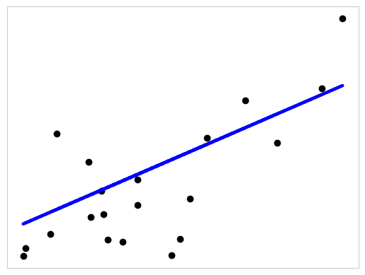

```python
from sklearn import linear_model, datasets
import matplotlib.pyplot as plt

# Load the diabetes dataset
diabetes_X, diabetes_y = datasets.load_diabetes(return_X_y=True)

# Use only one feature
diabetes_X = diabetes_X[:, np.newaxis, 2]

# Split the data into training/testing sets
diabetes_X_train = diabetes_X[:-20]
diabetes_X_test = diabetes_X[-20:]

# Split the targets into training/testing sets
diabetes_y_train = diabetes_y[:-20]
diabetes_y_test = diabetes_y[-20:]

# Create linear regression object
regr = linear_model.LinearRegression()

# Train the model using the training sets
regr.fit(diabetes_X_train, diabetes_y_train)

# Make predictions using the testing set
diabetes_y_pred = regr.predict(diabetes_X_test)

# Plot outputs
plt.scatter(diabetes_X_test, diabetes_y_test, color="black")
plt.plot(diabetes_X_test, diabetes_y_pred, color="blue", linewidth=3)

plt.xticks(())
plt.yticks(())

plt.show()
```

## Polars (dataframes for large-scale data processing)

The Polars library offers an alternative to Pandas dataframes that often performs much faster and uses less RAM for dataframe operations. Polars is built in [Rust](https://www.rust-lang.org/) while Pandas is built on NumPy, which has lower performance and higher memory use than Rust. Polars is also able to efficiently run parallel processes, adding to its improved performance.

```python
import sys
import time
import polars as pl
import pandas as pd

# how long does it take Polars to load in a CSV?
start_pl = time.time()
df_pl = pl.read_csv("library_data.csv")
end_pl = time.time()
print(f'Seconds for Polars to load in the library_data CSV: {end_pl-start_pl}')

# how long does it take Pandas to load in a CSV?
start_pd = time.time()
df_pd= pd.read_csv("library_data.csv")
end_pd = time.time()
print(f'Seconds for Pandas to load in the library_data CSV: {end_pd-start_pd}')

# how much faster is Polars?
print(f'Polars is {round((end_pd-start_pd)/(end_pl-start_pl), 2)}x faster')
```

```
Seconds for Polars to load in the library_data CSV: 0.048026084899902344
Seconds for Pandas to load in the library_data CSV: 0.013886213302612305
Polars is 0.29x faster
```

```python
# compare the memory size of the Polars and Pandas dataframes
print(f'The Polars dataframe takes up {sys.getsizeof(df_pl)} bytes.')
print(f'The Pandas dataframe takes up {sys.getsizeof(df_pd)} bytes.')
```

```
The Polars dataframe takes up 48 bytes.
The Pandas dataframe takes up 1972339 bytes.
```

## DuckDB (for creating a SQL Database)

DuckDB is a great library for setting up a SQL-database with Python. It does not have any dependencies and is very memory efficient, making it a faster alternative to PostgreSQL, MySQL, or SQLite.

```python
import duckdb

duckdb.read_csv("library_data.csv")
duckdb.sql("SELECT id, library, town, title FROM 'library_data.csv' WHERE town = 'Riverdale' LIMIT 10")
```

```
┌───────┬────────────────────────┬───────────┬──────────────────────────┐
│  id   │        library         │   town    │          title           │
│ int64 │        varchar         │  varchar  │         varchar          │
├───────┼────────────────────────┼───────────┼──────────────────────────┤
│  3384 │ Riverside Reading Room │ Riverdale │ The Dragon's Crown       │
│  1449 │ Riverside Reading Room │ Riverdale │ Time Paradox             │
│   921 │ Riverside Reading Room │ Riverdale │ Murder on Pine Street    │
│   931 │ Riverside Reading Room │ Riverdale │ Murder on Pine Street    │
│  4122 │ Riverside Reading Room │ Riverdale │ Philosophy Today         │
│   886 │ Riverside Reading Room │ Riverdale │ Murder on Pine Street    │
│  2404 │ Riverside Reading Room │ Riverdale │ The Great American Novel │
│  2488 │ Riverside Reading Room │ Riverdale │ Echoes of Yesterday      │
│  5680 │ Riverside Reading Room │ Riverdale │ The Perfect Crime        │
│  5767 │ Riverside Reading Room │ Riverdale │ Night Watch              │
├───────┴────────────────────────┴───────────┴──────────────────────────┤
│ 10 rows                                                     4 columns │
└───────────────────────────────────────────────────────────────────────┘
```

## BeautifulSoup (for parsing HTML or XML data)

Python's built-in `urllib.request` package makes it relatively easy to download the underlying html from a web page. Note that the `from <package> import <function>` notation used here allows you to selectively import only parts of a package as needed.

Be sure to check the terms of services for any website before scraping! We're scraping our own materials here to be safe!

```python
from urllib.request import urlopen
from bs4 import BeautifulSoup

# Scrape Python 1 materials!
page = urlopen("https://unc-libraries-data.github.io/Python/Session1/Session1_CrashCourse.html")
html = page.read()

# Parse the HTML
soup = BeautifulSoup(html,"html.parser")
[x.text for x in soup.find_all("h2")] # find all second-level headers
```

```
['Why Python?¶',
 'Getting Started¶',
 'Data Types and Variables¶',
 'Flow Control¶',
 'Review¶']
```

## NLTK (for text analysis)

[The Natural Language Toolkit (`nltk`)](http://www.nltk.org/) provides a wide array of tools for processing and analyzing text. This includes operations like splitting text into sentences or words ("tokenization"), tagging them with their part of speech, classification, and more.

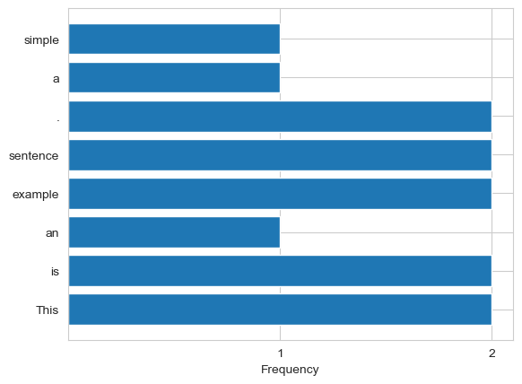

```python
import nltk
nltk.download('punkt_tab')
from nltk.tokenize import word_tokenize
from nltk.probability import FreqDist
import matplotlib.pyplot as plt

text = "This is an example sentence. This sentence is a simple example."

words = word_tokenize(text) # tokenize the text
fdist = FreqDist(words) # count how often each word occurs

# Show the frequencies
plt.figure()
plt.barh(fdist.keys(), fdist.values())
plt.xticks(range(1,3))
plt.xlabel('Frequency')
```

## PIL (Pillow)

[Pillow](https://pillow.readthedocs.io/en/stable/) is the updated version of the old Python Imaging Library (PIL), which provides fundamental tools for working with images. Pillow can work with a many common formats (some of which may require extra packages or other dependencies) to automate a wide variety of image transformations.

Note: While `pillow` is how you install the package, you import functions with `import PIL`.

Both `display` and `imshow` can be used to preview the image. Currently, `display` returns some errors due to the image's modes, so we're using `imshow` to avoid these errors. Read more about modes.

[figure not shown]

```python
from PIL import Image
from urllib.request import urlretrieve
from matplotlib.pyplot import imshow
from IPython.display import display

# download the unc logo
urlretrieve("https://identity.unc.edu/wp-content/uploads/sites/885/2019/01/UNC_logo_webblue-e1517942350314.png",
           "UNC_logo.png")

# open and display the image
UNC = Image.open("UNC_logo.png")
imshow(UNC)
```

[figure not shown]

```python
# resize the image and make it grayscale
# note: // divides two numbers and rounds the result down to get an integer
UNC_gray = UNC.convert('LA').resize((UNC.width//2,UNC.height//2))
imshow(UNC_gray)
```

## Parallel Processing with joblib

As you move into more complicated processes in Python (or applying code to a wide variety of objects or files), processing time can become a major factor. Fortunately, most modern laptops have multiple processor cores that can do separate things at the same time. Python only uses **one core** by default. If you have a set of loops that don't depend on each other (e.g. processing lots of files one after another), you could split up your many loop iterations between processors to greatly increase speed.

The [`joblib` package](https://joblib.readthedocs.io/en/latest/) provides a straightforward way to split loops up between your computers cores for faster performance on complicated code. Note that parallelization may not benefit you much or may even hurt you for very quick jobs because setting up and consolidating information from separate cores creates overhead costs.

# How to continue learning

- [Exercises](https://unc-libraries-data.github.io/Python/Intro/Exercises.html) and [solutions](https://unc-libraries-data.github.io/Python/Intro/Exercises_Solutions.html) for practicing Python
- [Exercises](https://unc-libraries-data.github.io/Python/Jupyter/PandasExercises.html) and [solutions](https://unc-libraries-data.github.io/Python/Jupyter/PandasSolutions.html) for praciticing Pandas
- [Practice Python](https://www.practicepython.org/)
- [Python Projects - Beginner to Advanced](https://www.geeksforgeeks.org/python/python-projects-beginner-to-advanced/)
- [Python Projects You Can Build](https://realpython.com/tutorials/projects/)
- [Automate the Boring Stuff with Python](https://automatetheboringstuff.com/)
- [Python Programming for the Humanities](http://www.karsdorp.io/python-course/)
- [Python Data Science Handbook](https://jakevdp.github.io/PythonDataScienceHandbook/) This free ebook emphasizes Numpy, Scipy, Matplotlib, Pandas and other data analysis packages in Python, assuming some familiarity with the basic principles of the language.
  - [Whirlwind Tour of Python](https://nbviewer.jupyter.org/github/jakevdp/WhirlwindTourOfPython/blob/master/Index.ipynb)
- Are you used to working in R? Check out this [Data manipulation R-Python conversion guide](https://www.mit.edu/~amidi/teaching/data-science-tools/conversion-guide/r-python-data-manipulation/) and [The Struggles I Had When Switching from R to Python](https://towardsdatascience.com/the-struggles-i-had-when-switching-from-r-to-python-baca0139b01b/)